# Fun size reproducibility presents…

## A line graph of firearm manufacturing

This is a brief reproduction of data analysis featured in an [article from AJPM](http://dx.doi.org/10.1016/j.amepre.2017.05.002) published on June 22, 2017. The authors used data from the [Bureau of Alcohol, Tobacco, Firearms, and Explosives](https://www.atf.gov/resource-center/data-statistics) to examine the number of guns manufactured in the United States from 1990-2015.

We reproduced Figure 1 using [R 3.4.1](https://www.r-project.org/) and the following packages: [*data.table*](https://cran.r-project.org/web/packages/data.table/data.table.pdf) (for reading in the online CSV file) and [*ggplot2*](https://cran.r-project.org/web/packages/ggplot2/ggplot2.pdf) (for creating the graph).

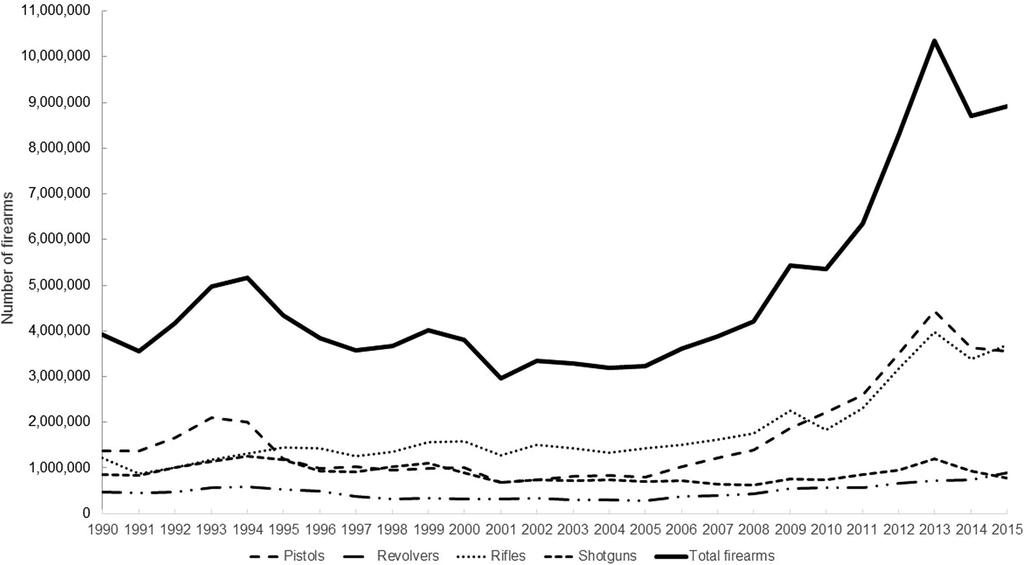

Domestic firearm production by type of weapon, 1990-2015.

### Libraries & data management

The data used in the paper were pulled from multiple publicly available sources, some of which were in spreadsheets on the [Bureau of Alcohol, Tobacco, Firearms, and Explosives website](https://www.atf.gov/resource-center/data-statistics) that were locked or disorganized pdf documents that were not easily imported. The data were also included in Table 1 of the paper, which could likely be scraped using R to automate the process, however, the paper is behind a paywall at [AJPM](https://doi.org/10.1016/j.amepre.2017.05.002) and is likely to be inaccessible to most. As a result, instead of bringing in raw data from the original source or the Table, we saved the contents of Table 1 as a comma separated values (CSV) file, [uploaded it to Github](https://raw.githubusercontent.com/coding2share/Fun-size-reproducibility/master/AJPM-Sept2017-firearm-manufacturing/total_firearms_manufactured_US_1990to2015.csv), and used it to reproduce the Figure.

Here we load the libraries, read in the data, and wrangle it into a useful dataset.

```r
library(data.table)
library(ggplot2)

#bring in the data copied from Table 1 and saved as csv
gunsManu <- fread("https://raw.githubusercontent.com/coding2share/Fun-size-reproducibility/master/AJPM-Sept2017-firearm-manufacturing/total_firearms_manufactured_US_1990to2015.csv")

#recode Year to be a character variable
gunsManu$Year <- as.character(gunsManu$Year)

#make the data long instead of wide
gunsManuLong <- melt(gunsManu, id.vars = "Year",
                     measure.vars = c("Pistols","Revolvers","Rifles","Shotguns","Total firearms"))

#rename the variables
names(gunsManuLong) <- c("Year","gunType","numGunsManu")
summary(gunsManuLong)
```

[output not shown]

### Analysis

The data were plotted without additional analyses.

### Plot

And the plot.

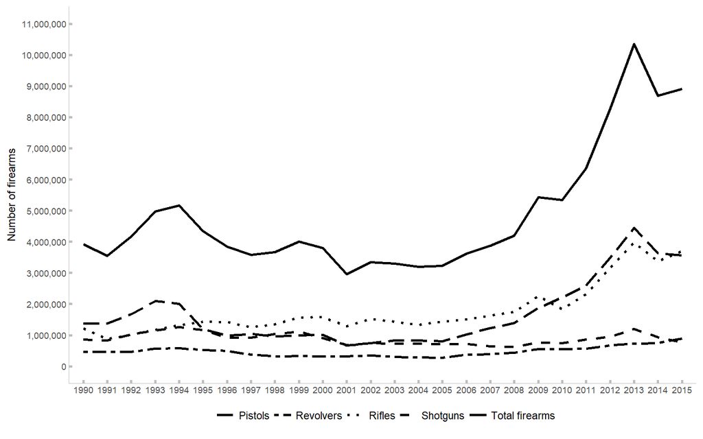

Domestic firearm production by type of weapon, 1990-2015.

```r
#plot it
ggplot(gunsManuLong, aes(x=Year, y=numGunsManu, group=gunType, linetype=gunType)) +
  geom_line(size=1) +
  theme_classic() +
  scale_y_continuous(labels = scales::comma, name="Number of firearms",
                     breaks=seq(0,11000000, by=1000000), limits=c(0,11000000)) +
  scale_x_discrete(name="") +
  scale_linetype_manual(values=c("longdash","twodash",
                                 "dotted","dashed","solid"),
                        name="") +
  theme(legend.position="bottom", axis.text = element_text(size = 7),
        axis.line = element_line(color = 'gray',size=0.1),
        axis.ticks = element_line(size=1,color='gray'),
        axis.ticks.length = unit(-.1, "cm"),
        axis.text.y = element_text(margin=margin(0,5,0,0,"pt")),
        axis.text.x = element_text(margin=margin(5,0,0,0,"pt")),
        legend.box.margin=margin(c(-20,0,0,0)),
        axis.title=element_text(size=9))
```